# WorldPhones Data Product Pitch

2016, 26 November

## WordPhones

WordPhones is a dataset included in R by default. It provides information about phone distributions along different regions.

```
##      N.Amer Europe Asia S.Amer Oceania Africa Mid.Amer
## 1951  45939  21574 2876   1815    1646     89      555
## 1956  60423  29990 4708   2568    2366   1411      733
```

The proposed app use the data for each region through a diversity of year to fit a basic linear model with the objective to predict the number of phones in future years

The application does not require any special requirement of imports from the user computer

## Available tabs: Documentation

The app is documenting covering three aspects:

- An introduction to the data set that has been used
- How the application should be used
- The technical details of the application

## Available tabs: Regresion

In this tab will be plotted the result of the model with the fitted line covering the regression line

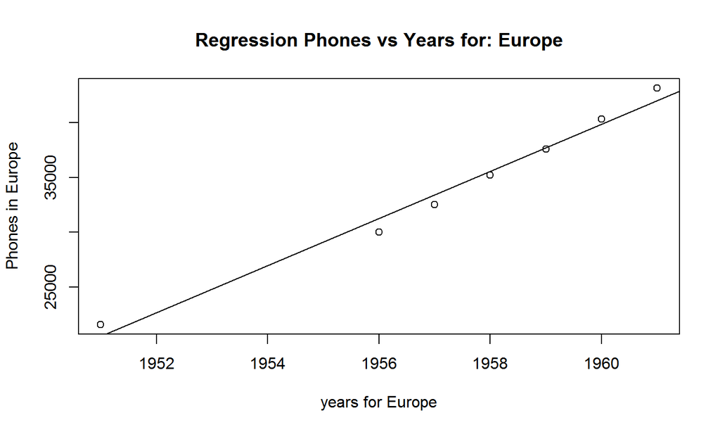

Additionally, The tab printed the results the model foreseen for the selected year

## Conclusions

The app is a simple application for regression and prediction, using reactive programming and interactivity with the user. This interactivity allows the user to control, both the resultand the presentation.

*Presentation*: There are three checks that controls the printing of the title, and the x,y legends. The checkboxes allow the user to select if the legends will appear

*Behavior*: The fit of the model is done in each case, but the selection of the region determine the data to be used. The user may select if a prediction is rquired and the year for that prediction for the selected region. For instance,for Europe, year 2000:

```
(Intercept)
   126117.5
```